# Spatial Configuration of Epigraphics

Joseph Lewis

10 February 2018

# What is an epigraphic?

An epigraph is any sort of text, and is a primary tool in archaeology when dealing with literate cultures.

# Data

The Epigraphic Database Heidelberg contains the find spots of ~ 25,000 ancient Lain and bilingual (usually Latin and Greek) inscriptions [Data Source](http://edh-www.adw.uni-heidelberg.de/data).

# Preparation

```r
library(jsonlite)
library(ggplot2)
library(tidyr)
library(nominatim)
library(ggmap)
library(maptools)
library(raster)
library(tmap)
library(rgeos)
```

Load data and extract the coordinates of the epigraphics.

```r
URL <- "http://edh-www.adw.uni-heidelberg.de/download/edhGeographicData.json"

epi <- fromJSON(txt = URL)

names(epi)
```

```
## [1] "type"     "features"
```

```r
epigraphics_loc <- epi$features$geometry

head(epigraphics_loc)
```

```
##    type                coordinates
## 1 Point 23.451654999, 38.497692999
## 2 Point 22.992664000, 37.915851400
## 3 Point    22.876113, 38.435817999
## 4 Point 22.992664000, 37.915851400
## 5 Point 25.190000000, 37.049999999
## 6 Point 25.228999999, 37.408999999
```

In order to use the coordinates, we need to clean them up.

```r
epigraphics_loc <- separate(epigraphics_loc, 2, c("x", "y"), ",")

epigraphics_loc$x <- gsub("[^0-9.-]", "", epigraphics_loc$x)
epigraphics_loc$y <- gsub("[^0-9.]", "", epigraphics_loc$y)

epigraphics_loc$x <- as.numeric(epigraphics_loc$x)
epigraphics_loc$y <- as.numeric(epigraphics_loc$y)

epigraphics_xy <- epigraphics_loc[,c(2,3)]

head(epigraphics_xy)
```

```
##          x        y
## 1 23.45165 38.49769
## 2 22.99266 37.91585
## 3 22.87611 38.43582
## 4 22.99266 37.91585
## 5 25.19000 37.05000
## 6 25.22900 37.40900
```

# Spatial Distribution of Epigraphics

Now we have the coordinate points, let’s get plotting!

[figure not shown]

Due to the number of points, it is is quite hard to discern areas that contain large numbers of epigraphic find spots.

[figure not shown]

```r
al1MAP + stat_bin2d(data=epigraphics_xy, aes(x= x, y= y), bins=100, alpha = 0.8) + coord_map() + scale_fill_gradientn(colours=heat.colors(4)) + labs(x = "Longitude", y = "Latitude", fill  = "Count of Epigraphics", caption = "Data from http://edh-www.adw.uni-heidelberg.de")
```

From the above plot, we can see that one location in Britain has a higher quantity of epigraphics relative to all other places in Britain. This is very likely the Hadrian’s Wall, however we will explore this further.

# Hadrian’s Wall?

```r
spdf <- SpatialPointsDataFrame(coords = epigraphics_xy, data = epigraphics_loc,
                               proj4string = CRS("+proj=longlat +datum=WGS84 +ellps=WGS84 +towgs84=0,0,0"))

spdf <- spTransform(spdf, CRS("+proj=tmerc +lat_0=49 +lon_0=-2 +k=0.9996012717 +x_0=400000 +y_0=-100000 +ellps=airy +towgs84=446.448,-125.157,542.06,0.15,0.247,0.842,-20.489 +units=m +no_defs"))

uk <- raster::getData('GADM', country='GBR', level=0)

uk <- spTransform(uk, CRS("+proj=tmerc +lat_0=49 +lon_0=-2 +k=0.9996012717 +x_0=400000 +y_0=-100000 +ellps=airy +towgs84=446.448,-125.157,542.06,0.15,0.247,0.842,-20.489 +units=m +no_defs"))

uk_epigraphs <- spdf[uk,] # selects points of spdf inside UK polygon. Uses overlay function from sp.
```

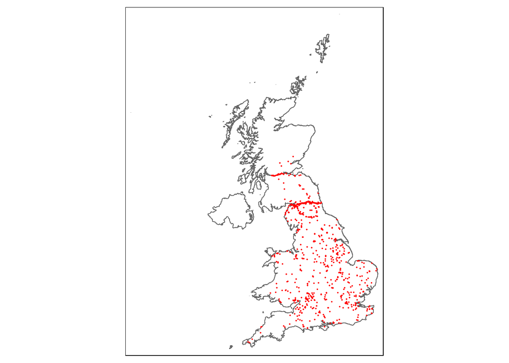

```r
tm_shape(uk) +
  tm_borders() +
tm_shape(uk_epigraphs) +
  tm_dots(col = "red")
```

It does look like there a lot of find spots along Hadrian’s Wall.

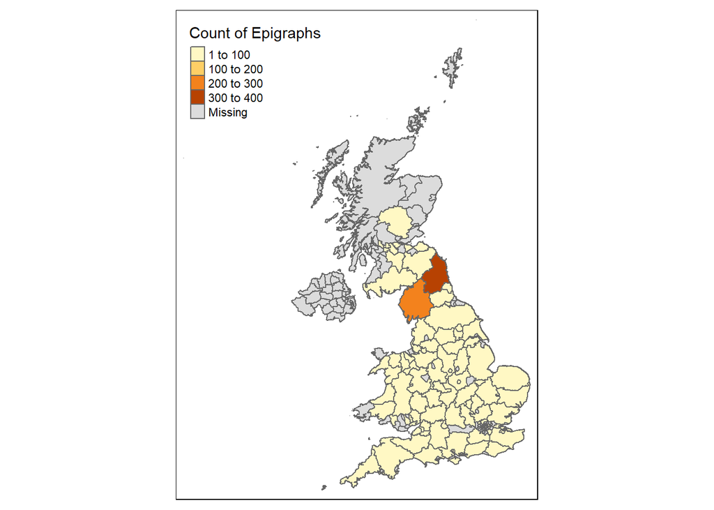

```r
counties <- raster::getData('GADM', country='GBR', level=2)

counties <- spTransform(counties, CRS("+proj=tmerc +lat_0=49 +lon_0=-2 +k=0.9996012717 +x_0=400000 +y_0=-100000 +ellps=airy +towgs84=446.448,-125.157,542.06,0.15,0.247,0.842,-20.489 +units=m +no_defs"))

pts_in_counties <- over(uk_epigraphs, counties)

pts_in_count<- as.data.frame(table(pts_in_counties$NAME_2))

test <- merge(counties, pts_in_count, by.x = "NAME_2", by.y = "Var1")

tm_shape(test) +
  tm_polygons(col = "Freq", n = 5, colorNA = "gainsboro", breaks = c(1,100,200,300,400), title= "Count of Epigraphs")
```

This is further exemplified when the count of Epigraphics per county is show. However, this view doesn’t take into account the size of the county. Therefore, we should normalise by the number of epigraphics by the area of each county.

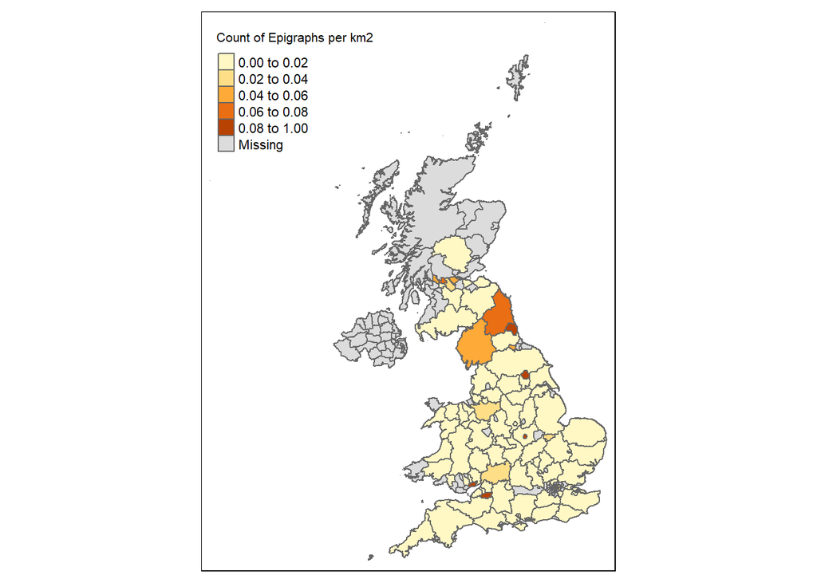

```r
test$area = gArea(test, byid = TRUE) / 1000^2

test$epiperarea <- test$Freq / test$area

tm_shape(test) +
  tm_polygons(col = "epiperarea", n = 5, colorNA = "gainsboro", breaks = c(0,0.02, 0.04, 0.06, 0.08, 1), title= "Count of Epigraphs per km2")
```

The higher quantity of epigraphics found in Britain remain in the counties that contain Hadrian’s Wall. Interestingly, the normalisation by area also identifies multiple small counties with a relatively large number of epigraphics per km2.